# Analysis 1: UNC Salaries

Dylan Francisco

July 04, 2023

# Instructions

**Overview:** For each question, show your R code that you used to answer each question in the provided chunks. When a written response is required, be sure to answer the entire question in complete sentences outside the code chunks. When figures are required, be sure to follow all requirements to receive full credit. Point values are assigned for every part of this analysis. **Do not work with other students on this assignment. You are to complete this assignment by yourself.**

**Helpful:** Make sure you knit the document as you go through the assignment. Check all your results in the created HTML file.

**Submission:** Submit via an electronic document on Canvas. Must be submitted as an HTML file generated in RStudio.

# Introduction

Universities are typically opaque, bureaucratic institutions. To be transparent to tax payers, many public schools, such as the University of North Carolina, openly report **[salary information](http://www.newsobserver.com/news/databases/public-salaries/)**. In this assignment, we will analyze this information from 2022 to answer pivotal questions that have endured over the course of time. The most recent salary data for UNC-Chapel Hill faculty and staff has already been downloaded in CSV format and titled *“Salary Data Export.csv”*.

To answer all the questions, you will need the R package `tidyverse` to make figures and utilize `dplyr` functions.

# Data Information

Make sure the CSV data file is contained in the folder of your RMarkdown file. First, we start by using the `read_csv` function from the `readr` package found within the tidyverse. The code below executes this process by creating a tibble in your R environment named “salary”.

```r
salary=read_csv("Salary Data Export.csv")
```

Now, we will explore the information that is contained in this dataset. The code below provides the names of the variables contained in the dataset.

```r
names(salary)
```

```
##  [1] "University" "Last_Name"  "First_Name" "INIT"       "Age"
##  [6] "Hire_Date"  "Category"   "Salary"     "Department" "Title"
```

Next, we will examine the type of data contains in these different variables.

```r
str(salary,give.attr=F)
```

```
## spc_tbl_ [13,001 × 10] (S3: spec_tbl_df/tbl_df/tbl/data.frame)
##  $ University: chr [1:13001] "UNC-CH" "UNC-CH" "UNC-CH" "UNC-CH" ...
##  $ Last_Name : chr [1:13001] "Jin" "Tien" "McManus" "Rizvi" ...
##  $ First_Name: chr [1:13001] "Guifeng" "Hsiao-Chuan" "James" "Imran" ...
##  $ INIT      : chr [1:13001] NA NA "M" NA ...
##  $ Age       : num [1:13001] 61 58 60 47 53 35 66 46 44 40 ...
##  $ Hire_Date : chr [1:13001] "1/27/1997" "11/1/2008" "1/13/2020" "7/1/2018" ...
##  $ Category  : chr [1:13001] "IT Database Professional, Database Administrator" "IT Database Professional, Data Administrator" "Research Professional, Mathematics / Computing / Statistics" "Assistant Professor" ...
##  $ Salary    : num [1:13001] 99998 99998 99988 99988 99975 ...
##  $ Department: chr [1:13001] "Carolina Population Center" "Carolina Population Center" "Renaissance Computing Inst" "Biomedical Engineering-UG" ...
##  $ Title     : chr [1:13001] "Applications Analyst" "Applications Analyst" "Research Scientist" "Assistant Professor" ...
```

You will notice that the variable “Hire_Date” is recorded as a character. The following code will first modify the original dataset to change this to a date variable with the format *mm/dd/yyyy*. Then, we will remove the hyphens to create a numeric variable as *yyyymmdd*. Finally, in the spirit of tidyverse, we will convert this data frame to a tibble.

```r
salary$Hire_Date=as.Date(salary$Hire_Date, format="%m/%d/%Y")
salary$Hire_Date=as.numeric(gsub("-","",salary$Hire_Date))
salary=as_tibble(salary)
```

Now, we will use `head()` to view of first five rows and the modifications made to the original data. The rest of the assignment will extend off this modified dataset named `salary` which by now should be in your global environment.

```r
head(salary,5)
```

```
## # A tibble: 5 × 10
##   University Last_Name First_Name  INIT    Age Hire_Date Category         Salary
##   <chr>      <chr>     <chr>       <chr> <dbl>     <dbl> <chr>             <dbl>
## 1 UNC-CH     Jin       Guifeng     <NA>     61  19970127 IT Database Pro… 99998
## 2 UNC-CH     Tien      Hsiao-Chuan <NA>     58  20081101 IT Database Pro… 99998
## 3 UNC-CH     McManus   James       M        60  20200113 Research Profes… 99988
## 4 UNC-CH     Rizvi     Imran       <NA>     47  20180701 Assistant Profe… 99988.
## 5 UNC-CH     O'HARA    RICHARD     J        53  19931213 Research Profes… 99975
## # ℹ 2 more variables: Department <chr>, Title <chr>
```

# Assignment

## Part 1: Reducing the Data to a Smaller Set of Interest

### Q1 *(2 Points)*

Create a new dataset named `salary2` that only contains the following variables:

- “Last_Name”
- “First_Name”
- “Age”
- “Hire_Date”
- “Category”
- “Salary”
- “Department”

Then, use the `names()` function to display the variable names of `salary2`.

```r
salary2 <- select(salary, Last_Name, First_Name, Age, Hire_Date, Category, Salary, Department)
names(salary2)
```

```
## [1] "Last_Name"  "First_Name" "Age"        "Hire_Date"  "Category"
## [6] "Salary"     "Department"
```

### Q2 *(2 Points)*

Now, we modify `salary2`. Rename the variables “Last_Name”,“First_Name”, and “Hire_Date” to “Last”,“First”, and “Hire”, respectively. Do this for a new dataset called `salary3` and use `names()` to display the variable names of `salary3`.

```r
salary3 <- rename(salary2, Last = Last_Name, First = First_Name, Hire = Hire_Date)
names(salary3)
```

```
## [1] "Last"       "First"      "Age"        "Hire"       "Category"
## [6] "Salary"     "Department"
```

### Q3 *(2 Points)*

Now, we modify `salary3`. Create a new variable called “HireYear” that only contains the first four digits of the variable “Hire_Date” in a new dataset named `salary4`. Use the function `str()` to ensure that your new variable “HireYear” reports the year of the date that the employee was hired.

```r
salary4 <- mutate(salary3, HireYear = substr(salary3$Hire, 1, 4))

str(salary4)
```

```
## tibble [13,001 × 8] (S3: tbl_df/tbl/data.frame)
##  $ Last      : chr [1:13001] "Jin" "Tien" "McManus" "Rizvi" ...
##  $ First     : chr [1:13001] "Guifeng" "Hsiao-Chuan" "James" "Imran" ...
##  $ Age       : num [1:13001] 61 58 60 47 53 35 66 46 44 40 ...
##  $ Hire      : num [1:13001] 19970127 20081101 20200113 20180701 19931213 ...
##  $ Category  : chr [1:13001] "IT Database Professional, Database Administrator" "IT Database Professional, Data Administrator" "Research Professional, Mathematics / Computing / Statistics" "Assistant Professor" ...
##  $ Salary    : num [1:13001] 99998 99998 99988 99988 99975 ...
##  $ Department: chr [1:13001] "Carolina Population Center" "Carolina Population Center" "Renaissance Computing Inst" "Biomedical Engineering-UG" ...
##  $ HireYear  : chr [1:13001] "1997" "2008" "2020" "2018" ...
```

### Q4 *(2 points)*

Now, we modify `salary4`. Create a new variable called “YrsEmployed” which reports the number of full years the employee has worked at UNC. Use the current year and assume that all employees are hired January 1. Create a new dataset named `salary5` and again use `str()` to display the variables in `salary5`.

```r
salary5 <- mutate(salary4, YrsEmployed = 2023 - as.numeric(HireYear))

str(salary5)
```

```
## tibble [13,001 × 9] (S3: tbl_df/tbl/data.frame)
##  $ Last       : chr [1:13001] "Jin" "Tien" "McManus" "Rizvi" ...
##  $ First      : chr [1:13001] "Guifeng" "Hsiao-Chuan" "James" "Imran" ...
##  $ Age        : num [1:13001] 61 58 60 47 53 35 66 46 44 40 ...
##  $ Hire       : num [1:13001] 19970127 20081101 20200113 20180701 19931213 ...
##  $ Category   : chr [1:13001] "IT Database Professional, Database Administrator" "IT Database Professional, Data Administrator" "Research Professional, Mathematics / Computing / Statistics" "Assistant Professor" ...
##  $ Salary     : num [1:13001] 99998 99998 99988 99988 99975 ...
##  $ Department : chr [1:13001] "Carolina Population Center" "Carolina Population Center" "Renaissance Computing Inst" "Biomedical Engineering-UG" ...
##  $ HireYear   : chr [1:13001] "1997" "2008" "2020" "2018" ...
##  $ YrsEmployed: num [1:13001] 26 15 3 5 30 2 24 3 12 9 ...
```

### Q5 *(3 points)*

Now, we modify `salary5` to create our final dataset named `salary.final`. Use the pipe `%>%` to make the following changes:

- Drop the variables “Hire”, “HireYear”, “First”, and “Last”.
- Sort the observations first by “YrsEmployed” and then by “Salary”, both in descending order from largest to smallest.
- Rearrange the variables so that “YrsEmployed” and “Salary” are the first two variables in the dataset, in that order, without removing any of the other variables.

After you have used the `%>%` to make these changes, use the function `head()` to display the first 12 rows of `salary.final`.

```r
salary.final <- salary5 %>%
  select(-c(Hire, HireYear, First, Last)) %>%
  arrange(desc(YrsEmployed), desc(Salary)) %>%
  select(YrsEmployed, Salary, everything())

head(salary.final, 12)
```

```
## # A tibble: 12 × 5
##    YrsEmployed  Salary   Age Category                                 Department
##          <dbl>   <dbl> <dbl> <chr>                                    <chr>
##  1          60  44500     88 Professor                                Psychiatr…
##  2          56 178479     80 Professor                                Computer …
##  3          56 165891     80 Professor                                Biostatis…
##  4          56 151716     80 Professor                                Political…
##  5          53 111917     79 Professor                                Economics
##  6          52 180408     77 Professor                                Cell Biol…
##  7          52 113221.    77 Professor                                Music
##  8          51  78972     69 Student Affairs / Student Services Prof… School of…
##  9          51  50328     68 Administrative Assistant                 SA Univer…
## 10          50  20000     82 Professor                                OBGYN-GYN…
## 11          49 300597     74 Assoc/Asst Provost                       OEVCP - P…
## 12          49 187135     76 Professor                                Earth Mar…
```

## Part 2: Answering Questions Based on All Data

In these questions,find the answer using code, and then answer the question using complete sentences below the code.

### Q6 *(3 Points)*

What is the difference between the median salary of employees in my department and the median salary of employees in Economics?

Code *(2 Points)*:

```r
EconMedian <- salary.final %>%
  filter(Department == "Economics") %>%
  select(Salary, Department)
StorMedian <- salary.final %>%
  filter(Department == "Statistics and Operations Res") %>%
  select(Salary, Department)
StorMedian
```

```
## # A tibble: 26 × 2
##     Salary Department
##      <dbl> <chr>
##  1 157986  Statistics and Operations Res
##  2 181538  Statistics and Operations Res
##  3 112526  Statistics and Operations Res
##  4 185391  Statistics and Operations Res
##  5 187148  Statistics and Operations Res
##  6 176160  Statistics and Operations Res
##  7 126349. Statistics and Operations Res
##  8 142143  Statistics and Operations Res
##  9  35394  Statistics and Operations Res
## 10 146181  Statistics and Operations Res
## # ℹ 16 more rows
```

```r
NegMedianDiff = median(StorMedian$Salary) - median(EconMedian$Salary)
NegMedianDiff
```

```
## [1] -21393.16
```

```r
PosMedianDiff = median(EconMedian$Salary) - median(StorMedian$Salary)
PosMedianDiff
```

```
## [1] 21393.16
```

Answer *(1 Point)*: (The difference in median salary between the Economics Department and the Statistics and Operations department is $21,393.16. This is one way you could summarize both data sets to determine that staff in the Economics department earn more than the Statistics and Operations department, but more analizing of the data would need to be done first before making that assumption)

### Q7 *(3 Points)*

What proportion of all employees in the “Professor” category are 60 years old or older?

Code *(2 Points)*:

```r
Professor60 <- salary.final %>%
  filter(Category == "Professor", Age >= 60) %>%
  select(Category, Age)

ProfessorTotal <- salary.final %>%
  filter(Category == "Professor")

Professor60.Prop = count(Professor60) / count(ProfessorTotal)
Professor60.Prop
```

```
##          n
## 1 0.478852
```

Answer *(1 Points)*: (The proportion of all professors that are 60 years or older is 0.478852. This means that approximately 47.89% of professors are at least 60 years old.)

### Q8 *(5 Points)*

For all the departments who have employees in the Lecturer category, which department spends the most money for this category and which department spends the least for this category? Also, for each of these departments, I want to know how many lecturers they have and the total amount of salary of all their lecturers.

Code *(4 Points)*:

```r
lecturer <- salary.final %>%
  filter(Category == "Lecturer") %>%
  group_by(Department) %>%
  summarise(TotalSalary = sum(Salary),
            Count = n()) %>%
  arrange(desc(TotalSalary)) %>%
  ungroup()

lecturer
```

```
## # A tibble: 49 × 3
##    Department                     TotalSalary Count
##    <chr>                                <dbl> <int>
##  1 Romance Studies                   1483339.    31
##  2 English and Comp Literature       1226210     24
##  3 Health Policy and Management      1178072.     9
##  4 SOG Sch of Government              861407      8
##  5 PH Leadership Program              803577      7
##  6 Asian & Middle Eastern Studies     798800     15
##  7 Biology                            621182      9
##  8 Psychology and Neuroscience        608248      9
##  9 Chemistry                          499386      7
## 10 Exercise and Sport Science         387482      6
## # ℹ 39 more rows
```

```r
TopAndBottom <- lecturer %>%
  filter(Department %in% c("Romance Studies", "Music"))

TopAndBottom
```

```
## # A tibble: 2 × 3
##   Department      TotalSalary Count
##   <chr>                 <dbl> <int>
## 1 Romance Studies    1483339.    31
## 2 Music                33220.     1
```

Answer *(1 Points)*: (The Romance Studies department spends the most money on lecturers and the Music department spends the least amount on lecturers. The Romance Studies department has 31 total lecturers and spends $1,483,339.14 and the Music department has 1 lecturer and spends $33,219.56)

## Part 3: Answering Questions Based on Summarized Data

### Q9 *(4 Points)*

Based off the data in `salary.final`, create a grouped summary based off combinations of “Department” and “Category”. Call the new tibble `dept_cat_summary`. Your summarized tibble, `dept_cat_summary`, should report all of the following statistics with corresponding variable names in the following order.

- “n” = number of employees for each combination
- “salary” = average salary for each combination
- “yrs” = average years employed for each combination
- “corr” = correlation between the salary and years employed for each combination

In the process, make sure you use `ungroup()` with the pipe `%>%` to release the grouping so future work is no longer group specific. Also, the `cor()` can be used to calculate the correlation between two variables.

Following the creation of `dept_cat_summary`, prove that your code worked by using `head()` to view the first 12 rows.

```r
dept_cat_summary <- salary.final %>%
  group_by(Department, Category) %>%
  summarise(n = n(),
            salary = mean(Salary),
            yrs = mean(YrsEmployed),
            corr = cor(Salary, YrsEmployed)) %>%
  ungroup()
head(dept_cat_summary, 12)
```

```
## # A tibble: 12 × 6
##    Department Category                                     n salary   yrs   corr
##    <chr>      <chr>                                    <int>  <dbl> <dbl>  <dbl>
##  1 AHEC       Accounting Professional, Dept Business …     1 8.36e4 17    NA
##  2 AHEC       Administrative / Office / Clerical Supp…     1 4.39e4  6    NA
##  3 AHEC       Administrative Assistant                     2 4.94e4  8    -1
##  4 AHEC       Administrative Specialist / Coordinator      2 1.48e5  7.5  -1
##  5 AHEC       Communications / Marketing Professional…     1 5.32e4  5    NA
##  6 AHEC       Community Development Professional           1 1.08e5 10    NA
##  7 AHEC       Executive Assistant                          1 5.47e4  1    NA
##  8 AHEC       Fiscal Affairs Paraprofessional              1 4.77e4 31    NA
##  9 AHEC       Functional Paraprofessional                  1 6.24e4  2    NA
## 10 AHEC       IT (Information Technology) Professional     3 1.13e5  7.67  0.985
## 11 AHEC       IT Applications Professional, Programme…     2 7.51e4 11    -1
## 12 AHEC       IT Database Professional, Data Administ…     1 1.12e5  9    NA
```

### Q10 *(4 Points)*

Using the summarized data in `dept_cat_summary`, use the `dplyr` functions to identify the 5 departments that have the most associate professors. The output should be a table that only shows the names of the 5 departments and the number of associate professors for each of the 5 departments.

Code:

```r
Associates <- dept_cat_summary %>%
  filter(Category == "Associate Professor") %>%
  arrange(desc(n)) %>%
  head(5) %>%
  select(Department, n)

Associates
```

```
## # A tibble: 5 × 2
##   Department                         n
##   <chr>                          <int>
## 1 Kenan-Flagler Bus Sch             30
## 2 Sch of Nursing                    25
## 3 Family Medicine                   20
## 4 SW-School of Social Work          20
## 5 School of Journalism and Media    20
```

### Q11 *(4 points)*

Create a scatter plot using `geom_point()` along with fitted linear regression lines using `geom_smooth` showing the linear relationship between average salary of Professors and the average years employed of Professors. Put the average years employed on the x-axis of your plot. **For this plot, use the summarized data in `dept_cat_summary` and exclude Departments where there are less than 5 professors.**

Following the plot, please explain what this plot suggests about the relationship between the average years employed and the average salary of professors. Make reference to the figure and use descriptive adjectives (i.e. “strong”, “weak”, etc.) and terms (i.e. “positive”, “negative”, etc.) that are appropriate for discussing linear relationships.

Code and Figure *(2 Points)*:

```r
Professors <- dept_cat_summary %>%
  filter(Category == "Professor", n >= 5)

Professors
```

```
## # A tibble: 81 × 6
##    Department                  Category      n  salary   yrs    corr
##    <chr>                       <chr>     <int>   <dbl> <dbl>   <dbl>
##  1 ASOD Pediatric Dentistry    Professor     6 193574   25   -0.380
##  2 Allied Health - PT          Professor     5 114967.  25   -0.750
##  3 American Studies            Professor     6 122358   21.5 -0.683
##  4 Anthropology                Professor     9 139180.  20.4  0.313
##  5 Art - Art History           Professor     8 127064.  20.4  0.528
##  6 Biochemistry and Biophysics Professor    18 156019.  29.9 -0.104
##  7 Biology                     Professor    33 144282.  25.4 -0.0113
##  8 Biostatistics               Professor    18 252728.  24.4 -0.433
##  9 Cell Biology and Physiology Professor    19 172957.  26.9 -0.455
## 10 Chemistry                   Professor    18 184343   23.5 -0.0509
## # ℹ 71 more rows
```

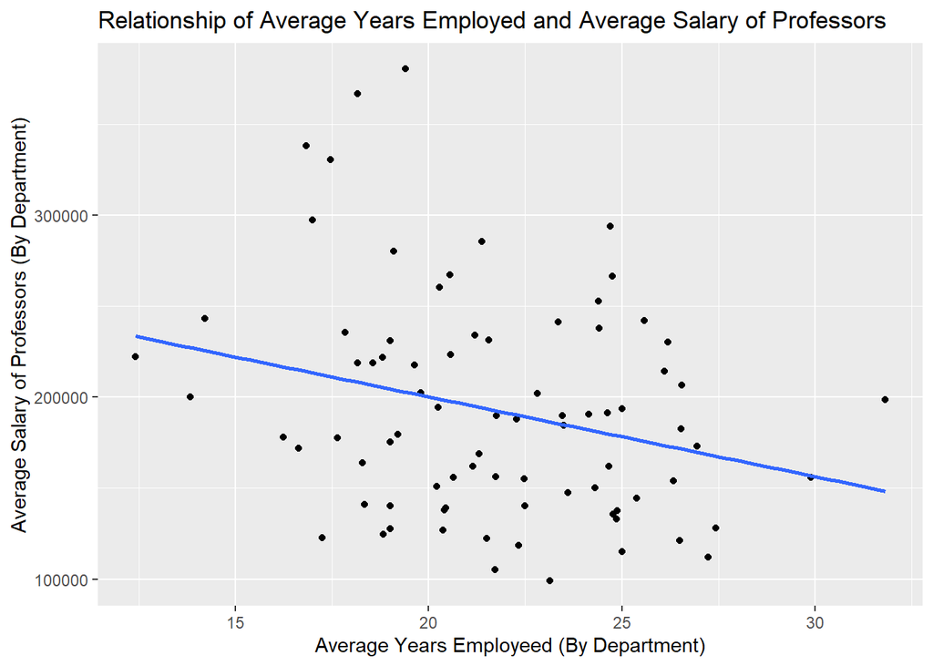

```r
ggplot(Professors, aes(x = yrs, y = salary)) +
  geom_point() +
  geom_smooth(method = "lm", se = FALSE) +
  labs(x = "Average Years Employeed (By Department)", y = "Average Salary of Professors (By Department)") +
  ggtitle("Relationship of Average Years Employed and Average Salary of Professors")
```

Answer *(2 Points)*: (According to the graph, we can see that there is a slight negative relationship between Average Years Employed and Average Salary of Professors. However, upon further examination we can see there are a few departments where the professors have an Average Years Employed around 15-20 that make an average salary of above $300,000. These are the highest values among the data and they somewhat skew the linear model. When we look at the Average Years Employed that is > 27.5, the values are in line with the other departments. Even so, the data is spread out well, making the linear model somewhat weak. Without those outliers, we may assume there is no correlation between the data.)

### Q12 *(6 Points)*

In `dept_cat_summary`, there are 750 unique departments. You can verify this by using `length(unique(dept_title_summary$Department))`. I want you to select only 3 academic departments not previously discussed or outputted in the assignment, and display the scatter plots and fitted linear regression lines representing the relationship between the average years employed and the average salary. Use `facet_wrap` so that each department has its own figure. Remove the shading of the confidence intervals for the regression lines. **For this plot, use the summarized data in `dept_cat_summary`.**

Then, in complete sentences, I want you to state what departments you chose and explain the differences and/or similarities between the groups based off the fitted linear regression lines.

Code and Figure: *(4 Points)*:

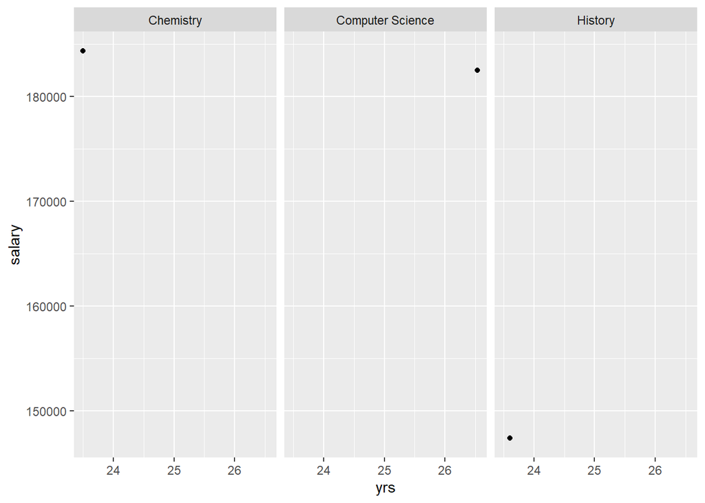

```r
SelectedDepartments = c("Computer Science", "Chemistry", "History")

SelectedDepData <- dept_cat_summary %>%
  filter(Department %in% SelectedDepartments, Category == "Professor")


ggplot(SelectedDepData, aes(x = yrs, y = salary)) +
  geom_point() +
  geom_smooth(method = "lm", se = FALSE) +
  facet_wrap(~ Department, nrow = 1)
```